# Protein Genes

**Libraries**

```r
library(rtracklayer)
library(GenomicFeatures)
library(txdbmaker)
library(Biostrings)
library(BSgenome)
library(BSgenomeForge)
library(dplyr)
library(GenomicRanges)
library(GenomeInfoDb)
library(Biostrings)
library(BSgenome)
library(ggplot2)
library(scales)
library(ggpointdensity)
```

**Loading data - Loading seqs + filtering**

```r
library(BSgenome.Dlaeve.NCBI.dlgm)
genome <- BSgenome.Dlaeve.NCBI.dlgm
```

```r
print(class(genome))
```

## [1] “BSgenome”

## attr(,“package”)

## [1] “BSgenome”

```r
length(genome)
```

## [1] 3497

```r
genome
```

## | BSgenome object

## | - organism: Deroceras laeve

## | - provider: NCBI

## | - genome: dl_gm

## | - 3497 sequence(s):

## | chr1 chr2 chr3 chr4

## | chr5 chr6 chr7 chr8

## | chr9 chr10 chr11 chr12

## | chr13 chr14 chr15 chr16

## | chr17 chr18 chr19 chr20

## | … … … …

## | HiC_scaffold_3481 HiC_scaffold_3482 HiC_scaffold_3483 HiC_scaffold_3484

## | HiC_scaffold_3485 HiC_scaffold_3486 HiC_scaffold_3487 HiC_scaffold_3488

## | HiC_scaffold_3489 HiC_scaffold_3490 HiC_scaffold_3491 HiC_scaffold_3492

## | HiC_scaffold_3493 HiC_scaffold_3494 HiC_scaffold_3495 HiC_scaffold_3496

## | HiC_scaffold_3497

## |

## | Tips: call ‘seqnames()’ on the object to get all the sequence names, call ‘seqinfo()’ to

## | get the full sequence info, use the ‘$’ or ‘[[’ operator to access a given sequence, see

## | ‘?BSgenome’ for more information.

```r
# names present in your BSgenome
nm  <- seqnames(genome)

# choose only proper chromosomes (e.g. chr1..chr31), ignore the HiC_scaffold zoo
keep <- intersect(paste0("chr", 1:31), nm)          # safe even if some are missing

# grab them quickly as a DNAStringSet (lightweight, fast)
genome_chr <- getSeq(genome, keep)

# sanity check
length(genome_chr); head(names(genome_chr))
```

## [1] 31## [1] “chr1” “chr2” “chr3” “chr4” “chr5” “chr6”

```r
transcriptome <- import("C:/Users/rafae/OneDrive/Desktop/Genomics/derLaeGenome_namesDlasi_v2.fasta.functional_note.pseudo_label.gff")
```

```r
transcriptome
```

## GRanges object with 1756563 ranges and 17 metadata columns:

## seqnames ranges strand | source type score

## |

## [1] HiC_scaffold_1005 6207-7268 - | EviAnn gene NA

## [2] HiC_scaffold_1005 6207-7268 - | EviAnn mRNA NA

## [3] HiC_scaffold_1005 6207-7268 - | EviAnn exon NA

## [4] HiC_scaffold_1005 6207-7268 - | EviAnn CDS NA

## [5] HiC_scaffold_1005 7529-9631 + | EviAnn gene NA

## … … … … . … … …

## [1756559] chr9 73153203-73153305 - | EviAnn CDS NA

## [1756560] chr9 73155022-73155165 - | EviAnn CDS NA

## [1756561] chr9 73157349-73157465 - | EviAnn CDS NA

## [1756562] chr9 73161856-73161986 - | EviAnn CDS NA

## [1756563] chr9 73179656-73179782 - | EviAnn CDS NA

## phase ID geneID gene_biotype

## [1] LOC_00034091 LOC_00034091 protein_coding

## [2] LOC_00034091-mRNA-1 LOC_00034091 protein_coding

## [3]

## [4] 0

## [5] LOC_00034092 LOC_00034092 protein_coding

## … … … … …

## [1756559] 0

## [1756560] 0

## [1756561] 0

… [43 líneas truncadas]

```r
table(transcriptome$gene_biotype)
```

## lncRNA processed_pseudogene protein_coding

## 1832 871 120268

```r
proteinGenes <- transcriptome[transcriptome$type == "gene" & transcriptome$gene_biotype == "protein_coding"]
length(proteinGenes)
```

## [1] 35105

```r
# keep only chromosomes present in genome_chr, drop scaffolds safely
proteinGenes <- keepSeqlevels(proteinGenes, seqlevels(genome_chr), pruning.mode = "coarse")

# now set seqinfo to match your chromosome-only genome
seqinfo(proteinGenes) <- seqinfo(genome_chr)
```

```r
geneinfo <- mcols(proteinGenes)[c("geneID","Note")]
geneinfo
```

## DataFrame with 23216 rows and 2 columns

## geneID Note

## 1 LOC_00005583 Similar to ems: Home..

## 2 LOC_00005584 Similar to Cyp20a1: ..

## 3 LOC_00005585 Similar to CNBD2: Cy..

## 4 LOC_00005586 function unknown

## 5 LOC_00005587 Similar to MTX1: Met..

## … … …

## 23212 LOC_00000986 Similar to P65-C: Sy..

## 23213 LOC_00000987 Similar to F52C9.6: ..

## 23214 LOC_00000988 function unknown

## 23215 LOC_00000990 Similar to QKI: KH d..

## 23216 LOC_00000989 function unknown

```r
proteinGenes <- trim(proteinGenes)
proteinGenes_seqs <- getSeq(genome_chr, proteinGenes)
```

*Body*

```r
length(proteinGenes_seqs)
```

## [1] 23216

```r
proteinGenes_seqs
```

## DNAStringSet object of length 23216:

## width seq

## [1] 69367 TGTCGAGCTGTGCTACCAAGTGGACCTGTCCGGGTC…GAAAAGTTTATTTTCTTTCAATAAAATGATTCCAT

## [2] 48705 AGACAAACTAGCCACGGCGATTGTTGTTGACATCTG…CGGTGTCATCTTTTCGTCTTCTGTATTCATTCGTC

## [3] 81790 TTTCTTTGGGCAACTCAAGTTTAGGCTGGGGCAACC…TATGATGATTAGGACTTGATGTATTAGCTCTAGAT

## [4] 414 ATGATTGGCGGGGCTGTGGTCAACGCCCTCGCGTTT…TGACGGGGTTTGTGGCTTATAAACTGGCTAAGTAA

## [5] 67391 ATGGCGAAAGACGGAATGAAATTGTCGGTCTGGAAA…CCAGTCTAACAAAAGACATGGAGATAGATAAATAA

## … … …

## [23212] 152630 ATAGACGATGTGGTATCTAGCAATATTTTCTCAAGC…AGGTACTACACCACAAGACAGTGGCCCAGTAGTGT

## [23213] 834 ATGAATAAAATAACCACAATGGCATACCAAGACCCG…TCACGACACTCGAAAGGGTACAAGTGAAAAGATAA

## [23214] 2404 GATGCATTGTACGAGCTTCTATTCATGGTTCCAAGA…TTTTTTGCTTTCGTTTTATTGGCTTGCCAAGTCAG

## [23215] 44493 GTCGGGTCTACCCAGTCTTAAGACGTCGGGTCTACC…TTGTAACAGACTTGTGGTGTTTGTCACAGACTTGT

## [23216] 360 ATGAGATGTGCATTAACACAGCCACATAGGAAGCCA…CAGCTTTATCTACATTAGCTGCCAGTATTTTGTAG

**Counting**

```r
letterFrequency_all <- letterFrequency(proteinGenes_seqs, c("A", "T", "C", "G")) %>% as.data.frame %>% tibble()
letterFrequency_all
```

| A | T | C | G |
| --- | --- | --- | --- |
| 14742 | 22102 | 19764 | 12759 |
| 9352 | 16650 | 14615 | 8088 |
| 19448 | 19919 | 26771 | 15652 |
| 102 | 91 | 97 | 124 |
| 13363 | 18267 | 11276 | 24485 |
| 3564 | 3163 | 2499 | 2764 |
| 1509 | 1466 | 1249 | 1286 |
| 27058 | 21349 | 22574 | 23778 |
| 7195 | 10316 | 9677 | 7243 |
| 8506 | 10684 | 7719 | 7513 |

[output cut: 9990 more lines]

```r
C_all <- letterFrequency_all[3]
G_all <- letterFrequency_all[4]
Width_all <- width(proteinGenes_seqs)
CG_all <- dinucleotideFrequency(proteinGenes_seqs)[,"CG"]
```

```r
OE_all = (CG_all*Width_all)/(C_all*G_all)
colnames(OE_all) <- c("OEindex")
OE_all
```

| OEindex |
| --- |
| 0.61975869 |
| 0.30119722 |
| 0.54966543 |
| 1.06701031 |
| 0.05784890 |
| 0.21871846 |
| 0.49741193 |
| 0.11333698 |
| 0.24070576 |
| 0.40896006 |

[output cut: 9990 more lines]

```r
cgContent_all = (C_all+G_all)/Width_all
colnames(cgContent_all) <- c("CGpercentage")
cgContent_all
```

| CGpercentage |
| --- |
| 0.4688541 |
| 0.4661328 |
| 0.5186820 |
| 0.5338164 |
| 0.5306495 |
| 0.4389491 |
| 0.4600726 |
| 0.4891567 |
| 0.4914176 |
| 0.4425077 |

[output cut: 9990 more lines]

```r
df <- cbind(OE_all,cgContent_all)
df
```

| OEindex | CGpercentage |
| --- | --- |
| 0.61975869 | 0.4688541 |
| 0.30119722 | 0.4661328 |
| 0.54966543 | 0.5186820 |
| 1.06701031 | 0.5338164 |
| 0.05784890 | 0.5306495 |
| 0.21871846 | 0.4389491 |
| 0.49741193 | 0.4600726 |
| 0.11333698 | 0.4891567 |
| 0.24070576 | 0.4914176 |
| 0.40896006 | 0.4425077 |

[output cut: 9990 more lines]

**Graphs**

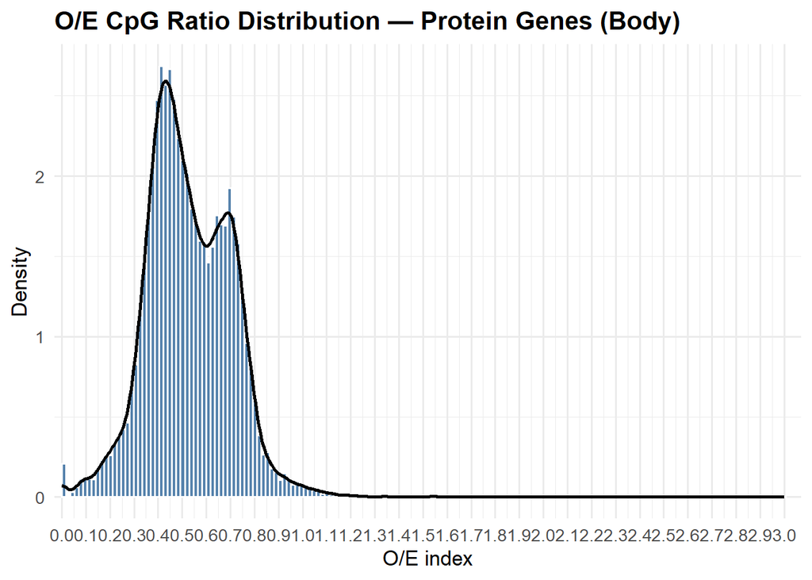

```r
x <- OE_all$OEindex
x <- x[is.finite(x)]
bw <- 2 * IQR(x) / length(x)^(1/3)
if (!is.finite(bw) || bw <= 0) bw <- diff(range(x)) / 80
xmin <- floor(min(x) * 10) / 10
xmax <- ceiling(max(x) * 10) / 10

ggplot(OE_all, aes(x = OEindex)) +
  geom_histogram(aes(y = after_stat(density)),
                 binwidth = bw, boundary = 0, closed = "left",
                 fill = "#4C7BA8", color = "white", alpha = 0.95) +
  geom_density(linewidth = 0.9, color = "black", alpha = 0.6) +
  scale_x_continuous(
    breaks = seq(xmin, xmax, by = 0.1),
    minor_breaks = seq(xmin, xmax, by = 0.05),
    labels = number_format(accuracy = 0.1),
    expand = expansion(mult = c(0.01, 0.02))
  ) +
  labs(
    title = "O/E CpG Ratio Distribution — Protein Genes (Body)",
    x = "O/E index",
    y = "Density"
  ) +
  theme_minimal(base_size = 13) +
  theme(
    panel.grid.minor = element_line(),
    plot.title = element_text(face = "bold")
  )
```

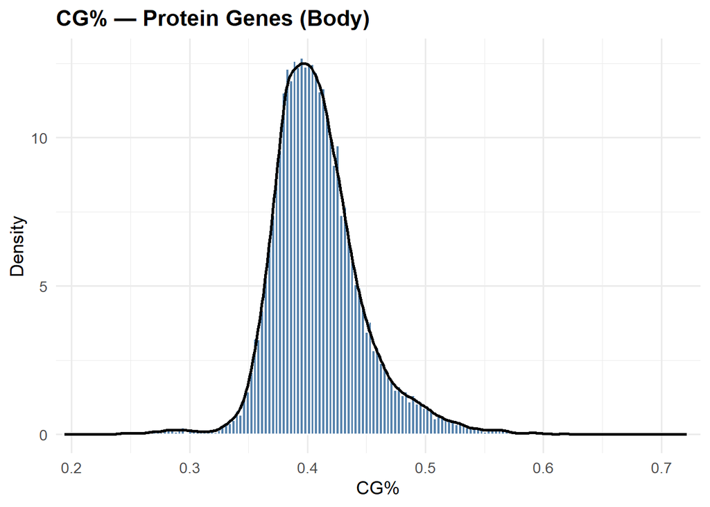

```r
x <- cgContent_all$CGpercentage
x <- x[is.finite(x)]
bw <- 2 * IQR(x) / length(x)^(1/3)
if (!is.finite(bw) || bw <= 0) bw <- diff(range(x)) / 80
xmin <- floor(min(x) * 10) / 10
xmax <- ceiling(max(x) * 10) / 10

ggplot(cgContent_all, aes(x = CGpercentage)) +
  geom_histogram(aes(y = after_stat(density)),
                 binwidth = bw, boundary = 0, closed = "left",
                 fill = "#4C7BA8", color = "white", alpha = 0.95) +
  geom_density(linewidth = 0.9, color = "black", alpha = 0.6) +
  scale_x_continuous(
    breaks = seq(xmin, xmax, by = 0.1),
    minor_breaks = seq(xmin, xmax, by = 0.05),
    labels = number_format(accuracy = 0.1),
    expand = expansion(mult = c(0.01, 0.02))
  ) +
  labs(
    title = "CG% — Protein Genes (Body)",
    x = "CG%",
    y = "Density"
  ) +
  theme_minimal(base_size = 13) +
  theme(
    panel.grid.minor = element_line(),
    plot.title = element_text(face = "bold")
  )
```

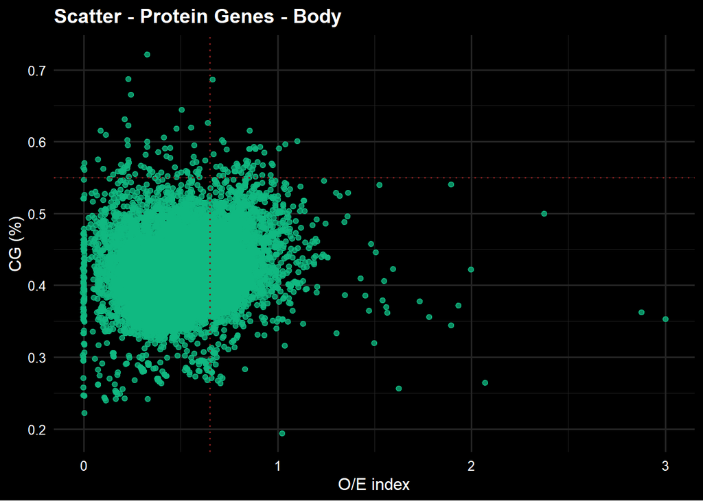

```r
plot_nice_dark <- function(d, x="OEindex", y="CGpercentage",
                           xthr=.65, ythr=.55, title="Scatter - Protein Genes - Body",
                           point_col="#10b981", thr_col="#7f1d1d"){   # green, violet
  dd <- data.frame(x=as.numeric(d[[x]]), y=as.numeric(d[[y]]))
  dd <- dd[is.finite(dd$x) & is.finite(dd$y), ]
  ggplot(dd, aes(x, y)) +
    geom_point(color=point_col, alpha=.75, size=1.6,
               position=position_jitter(width=.004, height=0)) +
    geom_vline(xintercept=xthr, color=thr_col, linewidth=.6, linetype="dotted") +
    geom_hline(yintercept=ythr, color=thr_col, linewidth=.6, linetype="dotted") +
    labs(title=title, x="O/E index", y="CG (%)") +
    theme_minimal(base_size=12) +
    theme(
      plot.background  = element_rect(fill="black", color=NA),
      panel.background = element_rect(fill="black", color=NA),
      panel.grid       = element_line(color="#242424"),
      axis.text        = element_text(color="white"),
      axis.title       = element_text(color="white"),
      plot.title       = element_text(color="white", face="bold")
    )
}

# use:
plot_nice_dark(df)
```

**PCA**

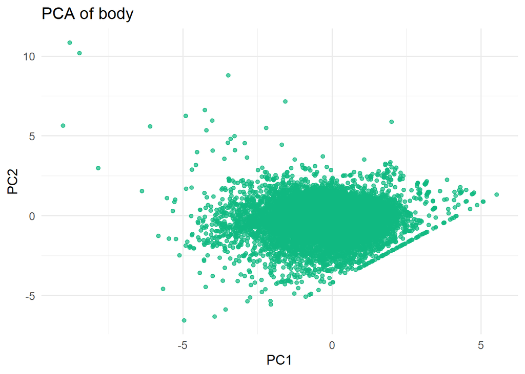

```r
# 1) Clean: keep numeric cols, drop NA/Inf rows, drop zero-variance cols
X <- df[, sapply(df, is.numeric), drop = FALSE]
X <- X[Reduce(`&`, lapply(X, is.finite)), , drop = FALSE]
X <- X[, sapply(X, function(z) sd(z) > 0), drop = FALSE]

# 2) PCA
pca <- prcomp(X, center = TRUE, scale. = TRUE)
pc  <- as.data.frame(pca$x[, 1:2, drop = FALSE])

ggplot(pc, aes(PC1, PC2)) +
  geom_point(alpha = .7, size = 1.6, color = "#10b981") +
  theme_minimal(base_size = 13) +
  labs(title = "PCA of body", x = "PC1", y = "PC2")
```

```r
summary(pca)
```

## Importance of components:

## PC1 PC2

## Standard deviation 1.1184 0.8656

## Proportion of Variance 0.6254 0.3746

## Cumulative Proportion 0.6254 1.0000

```r
cor(df$OEindex, df$CGpercentage)
```

## [1] NA

**K-Means**

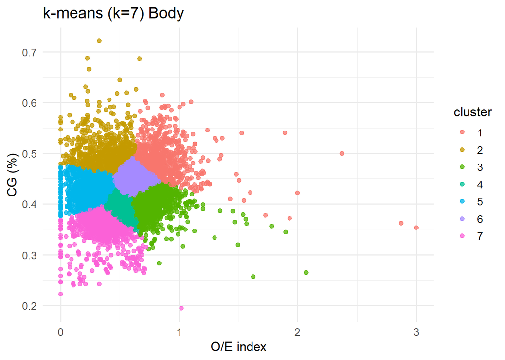

```r
# clean once; keep the mask so we can put labels back correctly
X <- df[, c("OEindex","CGpercentage")]
m <- is.finite(X$OEindex) & is.finite(X$CGpercentage)
Xc <- scale(X[m, , drop=FALSE])

set.seed(42)
k  <- 7
km <- kmeans(Xc, centers=k, nstart=50)

df$cluster <- NA_integer_
df$cluster[m] <- km$cluster
df$cluster <- factor(df$cluster)

ggplot(df[!is.na(df$cluster),], aes(OEindex, CGpercentage, color=cluster)) +
  geom_point(alpha=.75, size=1.7) +
  theme_minimal(base_size=13) +
  labs(title=sprintf("k-means (k=%d) Body", k),
       x="O/E index", y="CG (%)")
```

```r
#Add names
df <- cbind(geneinfo, df)
df
```

## DataFrame with 23216 rows and 5 columns

## geneID Note OEindex CGpercentage cluster

## 1 LOC_00005583 Similar to ems: Home.. 0.6197587 0.468854 6

## 2 LOC_00005584 Similar to Cyp20a1: .. 0.3011972 0.466133 2

## 3 LOC_00005585 Similar to CNBD2: Cy.. 0.5496654 0.518682 2

## 4 LOC_00005586 function unknown 1.0670103 0.533816 1

## 5 LOC_00005587 Similar to MTX1: Met.. 0.0578489 0.530649 2

## … … … … … …

## 23212 LOC_00000986 Similar to P65-C: Sy.. 0.399378 0.498329 2

## 23213 LOC_00000987 Similar to F52C9.6: .. 0.330729 0.381295 7

## 23214 LOC_00000988 function unknown 0.157750 0.385607 5

## 23215 LOC_00000990 Similar to QKI: KH d.. 0.403862 0.429079 5

## 23216 LOC_00000989 function unknown 0.188088 0.425000 5

```r
#Body list with cgi arquitecture
df_filtered_cgi_body <- dplyr::filter(as.data.frame(df), OEindex >= 0.65, CGpercentage >= .55)
df_filtered_cgi_body
```

| geneID | Note | OEindex | CGpercentage | cluster |
| --- | --- | --- | --- | --- |
| LOC_00005748 |  | 0.7776466 | 0.5641026 | 1 |
| LOC_00005974 |  | 0.8834483 | 0.5901639 | 1 |
| LOC_00006468 |  | 0.8498039 | 0.5532995 | 1 |
| LOC_00007237 |  | 0.8944880 | 0.5714286 | 1 |
| LOC_00007265 |  | 0.7829271 | 0.5590143 | 1 |
| LOC_00017541 |  | 0.7757717 | 0.5585586 | 1 |
| LOC_00017625 |  | 0.7431694 | 0.5580065 | 1 |
| LOC_00022859 |  | 0.9175935 | 0.5537190 | 1 |
| LOC_00025528 |  | 0.6947368 | 0.5530303 | 1 |
| LOC_00025762 |  | 0.9653888 | 0.5693215 | 1 |

[output cut: 39 more lines]

```r
C_all_sum <- sum(C_all)
G_all_sum <- sum(G_all)
Width_all_sum <- sum(width(proteinGenes_seqs))
CG_all_sum <- sum(CG_all)
```

```r
C_all_sum <- as.numeric(C_all_sum)
G_all_sum  <- as.numeric(G_all_sum)
Width_all_sum <- as.numeric(Width_all_sum)
CG_all_sum <- as.numeric(CG_all_sum)
```

```r
#CG% sum - Body
cgContent_all_sum <- (C_all_sum+G_all_sum)/Width_all_sum
cgContent_all_sum
```

## [1] 0.4189341

```r
#OE Index sum - Body
OE_all_sum <- (CG_all_sum*Width_all_sum)/(C_all_sum*G_all_sum)
OE_all_sum
```

## [1] 0.535684

```r
#Body sums totals
C_all_sum
```

## [1] 186150604

```r
G_all_sum
```

## [1] 182375739

```r
Width_all_sum
```

## [1] 879676104

```r
CG_all_sum
```

## [1] 20673660

```r
cgContent_all_sum
```

## [1] 0.4189341

```r
OE_all_sum
```

## [1] 0.535684

```r
#Porcentaje/Ratio de GCs en el cuerpo segun el span del cuerpo
CG_all_sum/Width_all_sum
```

## [1] 0.02350145

```r
#Porcentaje/Ratio de GC del cuerpo en comparacion al genoma
genomeCG_totalcount = 45535149
CG_all_sum/45535149
```

## [1] 0.4540154

*PROMOTORES*

```r
promotores_500bp <- promoters(proteinGenes, upstream = 2000, downstream = 0)


seqlevelsStyle(promotores_500bp) <- seqlevelsStyle(genome)
promotores_500bp <- keepSeqlevels(
  promotores_500bp,
  intersect(seqlevels(promotores_500bp), seqlevels(genome)),
  pruning.mode = "coarse"
)
seqinfo(promotores_500bp) <- seqinfo(genome)[seqlevels(promotores_500bp)]
promotores_500bp <- trim(promotores_500bp)

promotores_500bp <- promotores_500bp[width(promotores_500bp) > 0]

starts <- start(promotores_500bp)
ends   <- end(promotores_500bp)
lens   <- seqlengths(promotores_500bp)[as.character(seqnames(promotores_500bp))]
start(promotores_500bp) <- pmax(1L, starts)
end(promotores_500bp)   <- pmin(ends, lens)


seqs_promotores_500bp <- getSeq(genome, promotores_500bp)


length(seqs_promotores_500bp)
```

## [1] 23216

```r
seqs_promotores_500bp
```

## DNAStringSet object of length 23216:

## width seq

## [1] 2000 CTGAGCATGCTGAGAAGCACATCAACACAATTGAAAA…GGTTACCGAGGTGGCCAGGGAGGAAAGTCTCCATCG

## [2] 2000 CTTGTGCATTTTTTAAAAAGAATCACAATCGAAGGTT…CAGTTGCAGCTTTCCCAGAGTAGTTTCCCCTAGCCC

## [3] 2000 TGACCCCCAAACTTGGTCCACCATTGGGTGATACAGG…AGCTCAGCGACCGTGCTCGTCGACAGGCCAGGAGGT

## [4] 2000 TCTCCGAACACAGATTGGCGCGTTCAAAGCCCAAATC…GATATTCTGAAATAAGCAATGGCTTCCATCGCGCTC

## [5] 2000 TGGAAAGTCAAAAAGGTGTCGCATTGCTCGACAAGCC…TGGTTACCACTTCCGCTTCCGGTGTAATGTTTTAAA

## … … …

## [23212] 2000 AAGAGTCTCCTCGTCCTCTCCGCATAATTATTTGAGC…TATGGAGACACAGCTGCTGGTGACATTGACGTTACA

## [23213] 2000 GGCCTTACTTCAGTAGGCTATTACCTGGGTTTTGTTT…GGATGTGTCTTATCACCCCTATTATTTATAACTTAC

## [23214] 2000 ACCTGGAGGCAGGGGGGTGTGGAGAAATAGTTGCAGG…AGCGCCAGCTGATACTTGCCAACGACTATCAGTCAG

## [23215] 2000 CTCGTTGAAACCGCAAATGGCTCTTTAAATCATTGGA…GGTCACGACCGCTGGCAGCTCCTAGAAAACATTTAC

## [23216] 2000 GGCTGAGAAATTACCTCTTAGTTTTATGAGGCTGGGA…TGCTGAAAATTACACACCAAAAACACAGAAAGAAAT

**Counting**

```r
letterFrequency_all_promoters <- letterFrequency(seqs_promotores_500bp, c("A", "T", "C", "G")) %>% as.data.frame %>% tibble()
letterFrequency_all_promoters
```

| A | T | C | G |
| --- | --- | --- | --- |
| 565 | 445 | 474 | 516 |
| 589 | 463 | 527 | 421 |
| 405 | 587 | 507 | 501 |
| 502 | 493 | 475 | 530 |
| 517 | 545 | 441 | 497 |
| 672 | 405 | 565 | 358 |
| 597 | 450 | 525 | 428 |
| 516 | 457 | 473 | 554 |
| 611 | 562 | 409 | 418 |
| 604 | 655 | 378 | 363 |

[output cut: 9990 more lines]

```r
C_all_promoters <- letterFrequency_all_promoters[3]
G_all_promoters <- letterFrequency_all_promoters[4]
Width_all_promoters <- width(seqs_promotores_500bp)
CG_all_promoters <- dinucleotideFrequency(seqs_promotores_500bp)[,"CG"]
```

```r
C_all_promoters
```

| C |
| --- |
| 474 |
| 527 |
| 507 |
| 475 |
| 441 |
| 565 |
| 525 |
| 473 |
| 409 |
| 378 |

[output cut: 9990 more lines]

```r
G_all_promoters
```

| G |
| --- |
| 516 |
| 421 |
| 501 |
| 530 |
| 497 |
| 358 |
| 428 |
| 554 |
| 418 |
| 363 |

[output cut: 9990 more lines]

```r
Width_all_promoters
```

## [1] 2000 2000 2000 2000 2000 2000 2000 2000 2000 2000 2000 2000 2000 2000 2000 2000

## [17] 2000 2000 2000 2000 2000 2000 2000 2000 2000 2000 2000 2000 2000 2000 2000 2000

## [33] 2000 2000 2000 2000 2000 2000 2000 2000 2000 2000 2000 2000 2000 2000 2000 2000

## [49] 2000 2000 2000 2000 2000 2000 2000 2000 2000 2000 2000 2000 2000 2000 2000 2000

## [65] 2000 2000 2000 2000 2000 2000 2000 2000 2000 2000 2000 2000 2000 2000 2000 2000

## [81] 2000 2000 2000 2000 2000 2000 2000 2000 2000 2000 2000 2000 2000 2000 2000 2000

## [97] 2000 2000 2000 2000 2000 2000 2000 2000 2000 2000 2000 2000 2000 2000 2000 2000

## [113] 2000 2000 2000 2000 2000 2000 2000 2000 2000 2000 2000 2000 2000 2000 2000 2000

## [129] 2000 2000 2000 2000 2000 2000 2000 2000 2000 2000 2000 2000 2000 2000 2000 2000

## [145] 2000 2000 2000 2000 2000 2000 2000 2000 2000 2000 2000 2000 2000 2000 2000 2000

## [161] 2000 2000 2000 2000 2000 2000 2000 2000 2000 2000 2000 2000 2000 2000 2000 2000

## [177] 2000 2000 2000 2000 2000 2000 2000 2000 2000 2000 2000 2000 2000 2000 2000 2000

## [193] 2000 2000 2000 2000 2000 2000 2000 2000 2000 2000 2000 2000 2000 2000 2000 2000

## [209] 2000 2000 2000 2000 2000 2000 2000 2000 2000 2000 2000 2000 2000 2000 2000 2000

## [225] 2000 2000 2000 2000 2000 2000 2000 2000 2000 2000 2000 2000 2000 2000 2000 2000

## [241] 2000 2000 2000 2000 2000 2000 2000 2000 2000 2000 2000 2000 2000 2000 2000 2000

## [257] 2000 2000 2000 2000 2000 2000 2000 2000 2000 2000 2000 2000 2000 2000 2000 2000

## [273] 2000 2000 2000 2000 2000 2000 2000 2000 2000 2000 2000 2000 2000 2000 2000 2000

## [289] 2000 2000 2000 2000 2000 2000 2000 2000 2000 2000 2000 2000 2000 2000 2000 2000

## [305] 2000 2000 2000 2000 2000 2000 2000 2000 2000 2000 2000 2000 2000 2000 2000 2000

## [321] 2000 2000 2000 2000 2000 2000 2000 2000 2000 2000 2000 2000 2000 2000 2000 2000

## [337] 2000 2000 2000 2000 2000 2000 2000 2000 2000 2000 2000 2000 2000 2000 2000 2000

## [353] 2000 2000 2000 2000 2000 2000 2000 2000 2000 2000 2000 2000 2000 2000 2000 2000

## [369] 2000 2000 2000 2000 2000 2000 2000 2000 2000 2000 2000 2000 2000 2000 2000 2000

## [385] 2000 2000 2000 2000 2000 2000 2000 2000 2000 2000 2000 2000 2000 2000 2000 2000

… [1426 líneas truncadas]

```r
CG_all_promoters
```

## [1] 84 64 73 105 95 60 39 117 87 57 30 75 44 44 89 85 39 64 54 56

## [21] 26 31 127 43 56 103 12 37 88 31 98 61 65 134 90 97 33 113 112 114

## [41] 28 46 43 26 71 81 92 39 62 38 41 64 56 74 71 29 44 82 54 64

## [61] 75 56 58 59 62 63 68 51 56 66 60 43 91 56 49 50 64 47 37 71

## [81] 72 72 113 39 55 56 48 44 14 54 47 104 79 23 12 97 53 93 72 73

## [101] 49 40 27 86 79 57 49 34 77 54 27 63 57 81 95 71 45 66 72 65

## [121] 86 92 112 118 53 58 78 63 45 49 47 56 57 58 85 45 62 65 34 77

## [141] 31 64 57 50 55 61 58 15 13 25 27 67 53 43 70 25 34 68 69 84

## [161] 58 50 74 28 75 38 71 51 31 44 28 74 62 2 63 48 49 50 54 52

## [181] 60 113 35 80 35 66 61 51 24 58 55 67 44 68 54 30 69 58 49 71

## [201] 57 39 59 68 46 65 61 42 81 70 72 67 50 40 71 65 48 94 45 46

## [221] 69 77 72 59 49 46 50 74 50 72 27 49 68 47 57 68 58 50 17 48

## [241] 56 65 42 57 51 38 79 39 62 38 76 36 30 43 69 50 51 25 54 54

## [261] 37 48 62 48 111 72 71 53 72 68 64 32 45 55 56 53 66 24 60 32

## [281] 88 52 41 67 65 37 54 26 70 47 53 62 58 76 74 17 101 24 72 51

## [301] 61 90 43 72 18 104 67 35 33 45 61 10 61 60 51 53 59 61 40 61

## [321] 44 49 17 54 35 84 53 77 27 78 63 46 61 72 62 71 65 58 51 68

## [341] 75 50 53 48 53 55 44 22 52 72 95 66 51 47 37 58 62 62 60 66

## [361] 59 18 38 64 108 82 57 35 62 60 62 44 51 47 67 27 72 64 60 25

## [381] 43 62 50 37 42 47 32 95 62 53 102 21 61 57 79 59 68 75 65 29

## [401] 20 74 64 53 77 62 18 52 40 55 65 49 59 83 53 70 76 37 36 32

## [421] 60 50 52 82 61 44 68 57 71 56 58 55 55 28 24 45 35 83 48 9

## [441] 80 71 66 58 52 43 56 63 57 43 32 19 41 37 81 88 56 61 55 26

## [461] 56 53 29 20 57 70 39 28 41 32 52 63 41 76 53 38 25 68 64 45

## [481] 44 75 76 62 33 78 69 28 28 37 75 53 62 21 73 38 72 24 41 13

… [1136 líneas truncadas]

```r
OE_all_promoters = (CG_all_promoters*Width_all_promoters)/(C_all_promoters*G_all_promoters)
colnames(OE_all_promoters) <- c("OEindex")
OE_all_promoters
```

| OEindex |
| --- |
| 0.68688058 |
| 0.57692221 |
| 0.57478731 |
| 0.83416087 |
| 0.86687928 |
| 0.59326643 |
| 0.34712951 |
| 0.89298662 |
| 1.01777003 |
| 0.83081901 |

[output cut: 9990 more lines]

```r
cgContent_all_promoters = (C_all_promoters+G_all_promoters)/Width_all_promoters
colnames(cgContent_all_promoters) <- c("CGpercentage")
cgContent_all_promoters
```

| CGpercentage |
| --- |
| 0.4950 |
| 0.4740 |
| 0.5040 |
| 0.5025 |
| 0.4690 |
| 0.4615 |
| 0.4765 |
| 0.5135 |
| 0.4135 |
| 0.3705 |

[output cut: 9990 more lines]

```r
df_promoters <- cbind(OE_all_promoters,cgContent_all_promoters)
df_promoters
```

| OEindex | CGpercentage |
| --- | --- |
| 0.68688058 | 0.4950 |
| 0.57692221 | 0.4740 |
| 0.57478731 | 0.5040 |
| 0.83416087 | 0.5025 |
| 0.86687928 | 0.4690 |
| 0.59326643 | 0.4615 |
| 0.34712951 | 0.4765 |
| 0.89298662 | 0.5135 |
| 1.01777003 | 0.4135 |
| 0.83081901 | 0.3705 |

[output cut: 9990 more lines]

**Graphs**

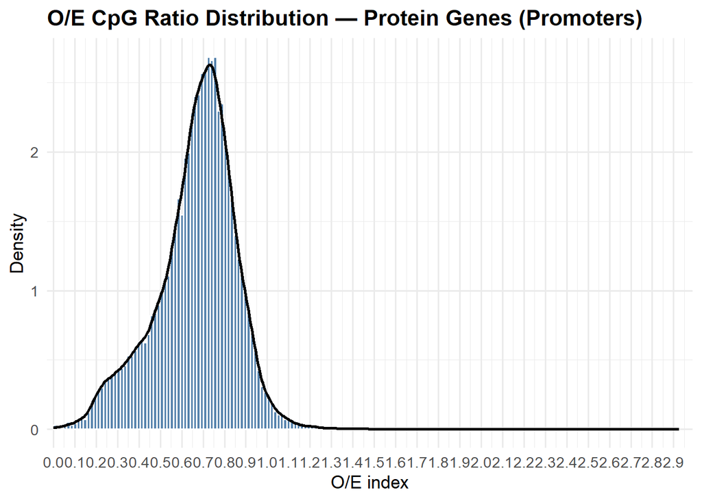

```r
x <- OE_all_promoters$OEindex
x <- x[is.finite(x)]
bw <- 2 * IQR(x) / length(x)^(1/3)
if (!is.finite(bw) || bw <= 0) bw <- diff(range(x)) / 80
xmin <- floor(min(x) * 10) / 10
xmax <- ceiling(max(x) * 10) / 10

ggplot(OE_all_promoters, aes(x = OEindex)) +
  geom_histogram(aes(y = after_stat(density)),
                 binwidth = bw, boundary = 0, closed = "left",
                 fill = "#4C7BA8", color = "white", alpha = 0.95) +
  geom_density(linewidth = 0.9, color = "black", alpha = 0.6) +
  scale_x_continuous(
    breaks = seq(xmin, xmax, by = 0.1),
    minor_breaks = seq(xmin, xmax, by = 0.05),
    labels = number_format(accuracy = 0.1),
    expand = expansion(mult = c(0.01, 0.02))
  ) +
  labs(
    title = "O/E CpG Ratio Distribution — Protein Genes (Promoters)",
    x = "O/E index",
    y = "Density"
  ) +
  theme_minimal(base_size = 13) +
  theme(
    panel.grid.minor = element_line(),
    plot.title = element_text(face = "bold")
  )
```

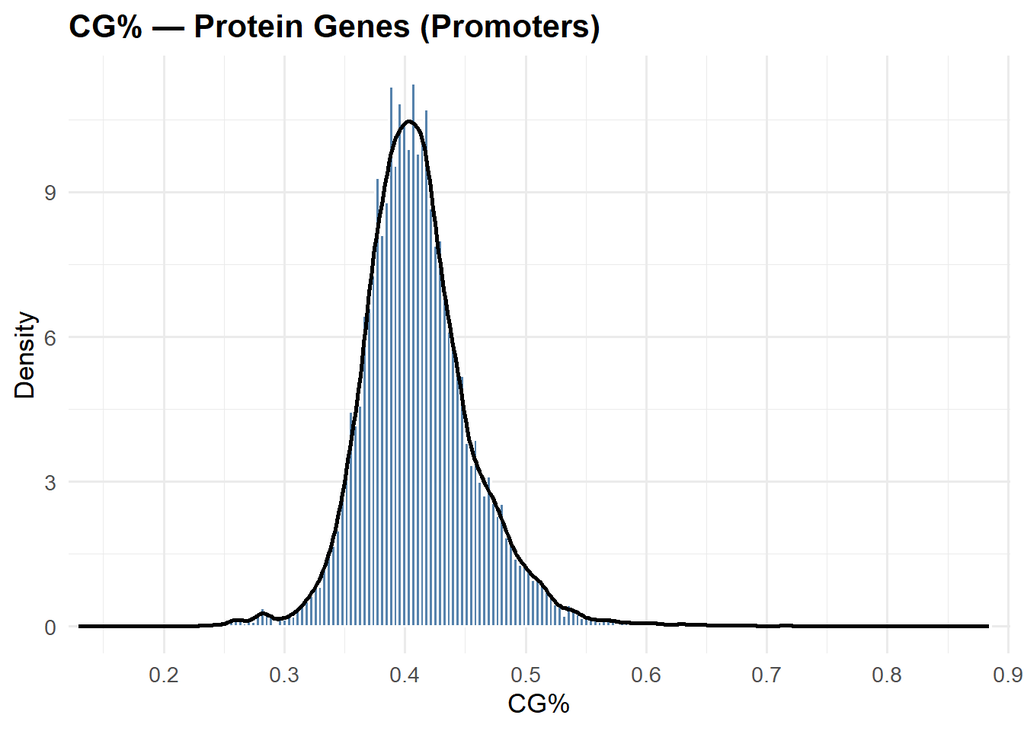

```r
x <- cgContent_all_promoters$CGpercentage
x <- x[is.finite(x)]
bw <- 2 * IQR(x) / length(x)^(1/3)
if (!is.finite(bw) || bw <= 0) bw <- diff(range(x)) / 80
xmin <- floor(min(x) * 10) / 10
xmax <- ceiling(max(x) * 10) / 10

ggplot(cgContent_all_promoters, aes(x = CGpercentage)) +
  geom_histogram(aes(y = after_stat(density)),
                 binwidth = bw, boundary = 0, closed = "left",
                 fill = "#4C7BA8", color = "white", alpha = 0.95) +
  geom_density(linewidth = 0.9, color = "black", alpha = 0.6) +
  scale_x_continuous(
    breaks = seq(xmin, xmax, by = 0.1),
    minor_breaks = seq(xmin, xmax, by = 0.05),
    labels = number_format(accuracy = 0.1),
    expand = expansion(mult = c(0.01, 0.02))
  ) +
  labs(
    title = "CG% — Protein Genes (Promoters)",
    x = "CG%",
    y = "Density"
  ) +
  theme_minimal(base_size = 13) +
  theme(
    panel.grid.minor = element_line(),
    plot.title = element_text(face = "bold")
  )
```

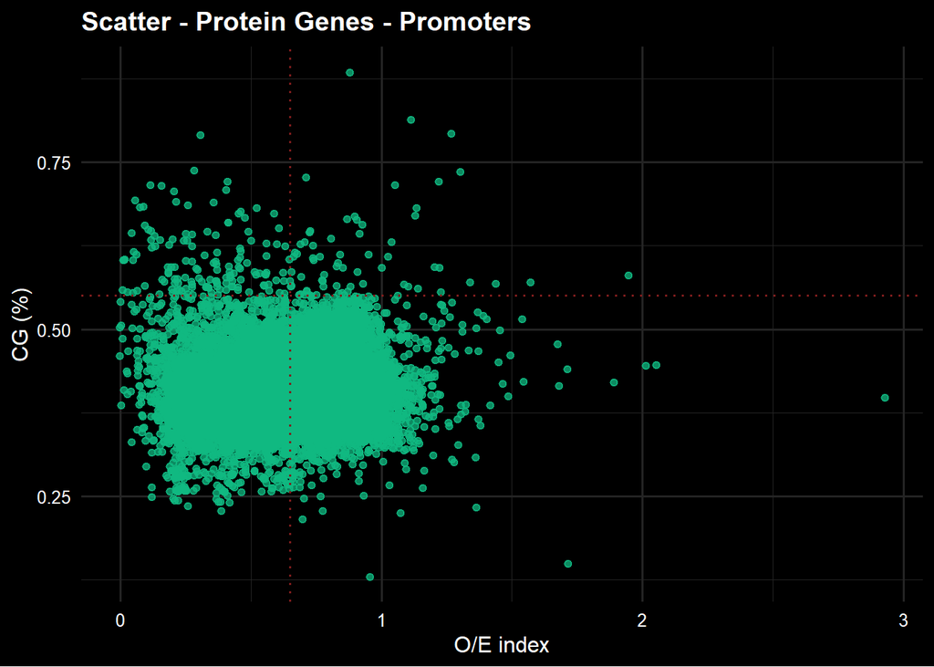

```r
plot_nice_dark <- function(d, x="OEindex", y="CGpercentage",
                           xthr=.65, ythr=.55, title="Scatter - Protein Genes - Promoters",
                           point_col="#10b981", thr_col="#7f1d1d"){   # green, violet
  dd <- data.frame(x=as.numeric(d[[x]]), y=as.numeric(d[[y]]))
  dd <- dd[is.finite(dd$x) & is.finite(dd$y), ]
  ggplot(dd, aes(x, y)) +
    geom_point(color=point_col, alpha=.75, size=1.6,
               position=position_jitter(width=.004, height=0)) +
    geom_vline(xintercept=xthr, color=thr_col, linewidth=.6, linetype="dotted") +
    geom_hline(yintercept=ythr, color=thr_col, linewidth=.6, linetype="dotted") +
    labs(title=title, x="O/E index", y="CG (%)") +
    theme_minimal(base_size=12) +
    theme(
      plot.background  = element_rect(fill="black", color=NA),
      panel.background = element_rect(fill="black", color=NA),
      panel.grid       = element_line(color="#242424"),
      axis.text        = element_text(color="white"),
      axis.title       = element_text(color="white"),
      plot.title       = element_text(color="white", face="bold")
    )
}

# use:
plot_nice_dark(df_promoters)
```

**PCA**

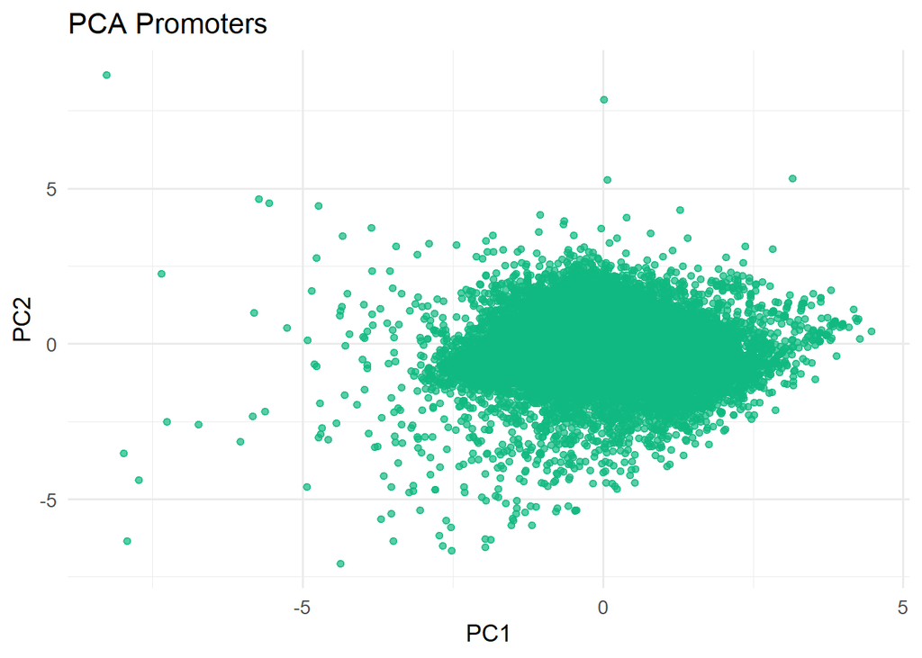

```r
# 1) Clean: keep numeric cols, drop NA/Inf rows, drop zero-variance cols
X <- df_promoters[, sapply(df_promoters, is.numeric), drop = FALSE]
X <- X[Reduce(`&`, lapply(X, is.finite)), , drop = FALSE]
X <- X[, sapply(X, function(z) sd(z) > 0), drop = FALSE]

# 2) PCA
pca <- prcomp(X, center = TRUE, scale. = TRUE)
pc  <- as.data.frame(pca$x[, 1:2, drop = FALSE])

ggplot(pc, aes(PC1, PC2)) +
  geom_point(alpha = .7, size = 1.6, color = "#10b981") +
  theme_minimal(base_size = 13) +
  labs(title = "PCA Promoters", x = "PC1", y = "PC2")
```

```r
summary(pca)
```

## Importance of components:

## PC1 PC2

## Standard deviation 1.0397 0.9587

## Proportion of Variance 0.5404 0.4596

## Cumulative Proportion 0.5404 1.0000

```r
cor(df$OEindex, df$CGpercentage)
```

## [1] NA

**K-Means**

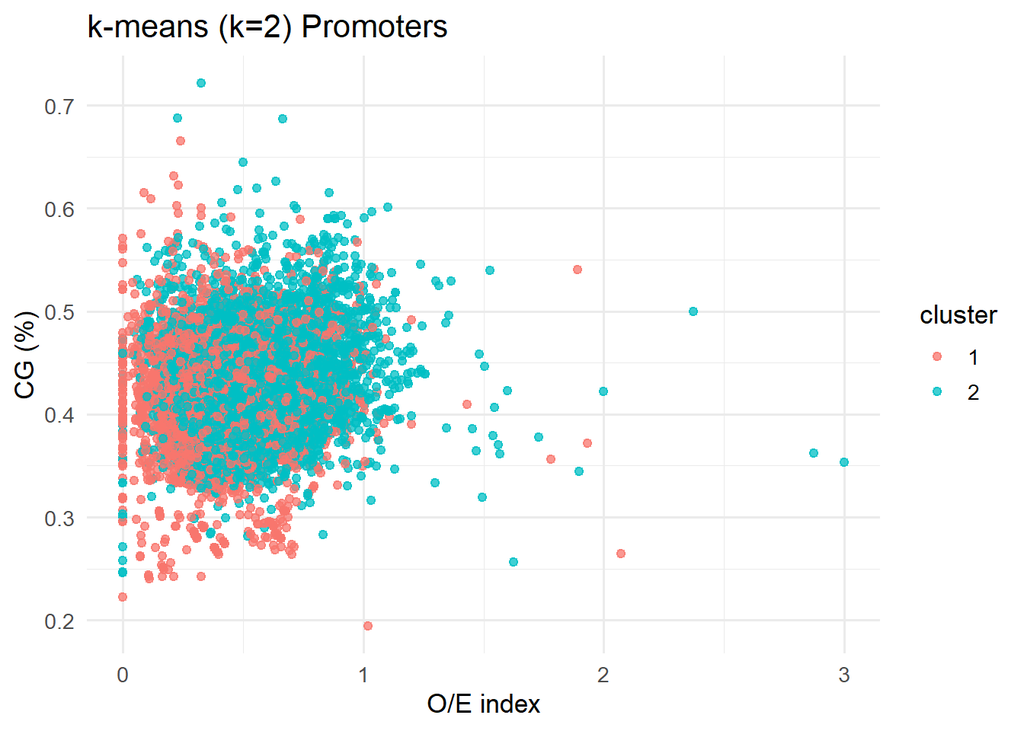

```r
# clean once; keep the mask so we can put labels back correctly
X <- df_promoters[, c("OEindex","CGpercentage")]
m <- is.finite(X$OEindex) & is.finite(X$CGpercentage)
Xc <- scale(X[m, , drop=FALSE])

set.seed(42)
k  <- 2
km <- kmeans(Xc, centers=k, nstart=50)

df$cluster <- NA_integer_
df$cluster[m] <- km$cluster
df$cluster <- factor(df$cluster)

ggplot(df[!is.na(df$cluster),], aes(OEindex, CGpercentage, color=cluster)) +
  geom_point(alpha=.75, size=1.7) +
  theme_minimal(base_size=13) +
  labs(title=sprintf("k-means (k=%d) Promoters", k),
       x="O/E index", y="CG (%)")
```

```r
#Add names
df_promoters <- cbind(geneinfo, df_promoters)
df_promoters
```

## DataFrame with 23216 rows and 4 columns

## geneID Note OEindex CGpercentage

## 1 LOC_00005583 Similar to ems: Home.. 0.686881 0.4950

## 2 LOC_00005584 Similar to Cyp20a1: .. 0.576922 0.4740

## 3 LOC_00005585 Similar to CNBD2: Cy.. 0.574787 0.5040

## 4 LOC_00005586 function unknown 0.834161 0.5025

## 5 LOC_00005587 Similar to MTX1: Met.. 0.866879 0.4690

## … … … … …

## 23212 LOC_00000986 Similar to P65-C: Sy.. 0.670831 0.3785

## 23213 LOC_00000987 Similar to F52C9.6: .. 0.456178 0.4245

## 23214 LOC_00000988 function unknown 0.323335 0.4260

## 23215 LOC_00000990 Similar to QKI: KH d.. 0.874763 0.4465

## 23216 LOC_00000989 function unknown 0.368528 0.3700

```r
#Promoters list with cgi arquitecture
df_filtered_cgi_promoters <- dplyr::filter(as.data.frame(df_promoters), OEindex >= 0.65, CGpercentage >= .55)
df_filtered_cgi_promoters
```

| geneID | Note | OEindex | CGpercentage |
| --- | --- | --- | --- |
| LOC_00005618 |  | 0.8429505 | 0.6120 |
| LOC_00006432 |  | 0.7679786 | 0.6085 |
| LOC_00006468 |  | 0.8583511 | 0.5515 |
| LOC_00007239 |  | 0.9519551 | 0.6120 |
| LOC_00016931 |  | 1.0595861 | 0.5500 |
| LOC_00017309 |  | 1.3371765 | 0.5705 |
| LOC_00022515 |  | 1.0504202 | 0.7160 |
| LOC_00022574 |  | 1.4358124 | 0.5685 |
| LOC_00025427 |  | 1.2202982 | 0.5920 |
| LOC_00025847 |  | 1.2626263 | 0.7925 |

[output cut: 57 more lines]

**Promoters Sum Count**

```r
C_all_sum_promoters <- sum(C_all_promoters)
G_all_sum_promoters <- sum(G_all_promoters)
Width_all_sum_promoters <- sum(width(seqs_promotores_500bp))
CG_all_sum_promoters <- sum(CG_all_promoters)
```

```r
C_all_sum_promoters <- as.numeric(C_all_sum_promoters)
G_all_sum_promoters  <- as.numeric(G_all_sum_promoters)
Width_all_sum_promoters <- as.numeric(Width_all_sum_promoters)
CG_all_sum_promoters <- as.numeric(CG_all_sum_promoters)
```

```r
C_all_sum_promoters
```

## [1] 9612134

```r
G_all_sum_promoters
```

## [1] 9470554

```r
Width_all_sum_promoters
```

## [1] 46432000

```r
CG_all_sum_promoters
```

## [1] 1293415

```r
#CG% sum - Body
cgContent_all_sum_promoters <- (C_all_sum_promoters+G_all_sum_promoters)/Width_all_sum_promoters
cgContent_all_sum_promoters
```

## [1] 0.4109814

```r
#OE Index sum - Body
OE_all_sum_promoters <- (CG_all_sum_promoters*Width_all_sum_promoters)/(C_all_sum_promoters*G_all_sum_promoters)
OE_all_sum_promoters
```

## [1] 0.6597207

```r
#Body sums totals
C_all_sum_promoters
```

## [1] 9612134

```r
G_all_sum_promoters
```

## [1] 9470554

```r
Width_all_sum_promoters
```

## [1] 46432000

```r
CG_all_sum_promoters
```

## [1] 1293415

```r
cgContent_all_sum_promoters
```

## [1] 0.4109814

```r
OE_all_sum_promoters
```

## [1] 0.6597207

```r
#Porcentaje/Ratio de GCs en el cuerpo segun el span del promoters
CG_all_sum_promoters/Width_all_sum_promoters
```

## [1] 0.02785611

```r
#Porcentaje/Ratio de GC del cuerpo en comparacion al genoma
genomeCG_totalcount = 45535149
CG_all_sum_promoters/45535149
```

## [1] 0.02840476